# Week 4 - in class discussion materials

### Repeat the above steps, but color code by probe

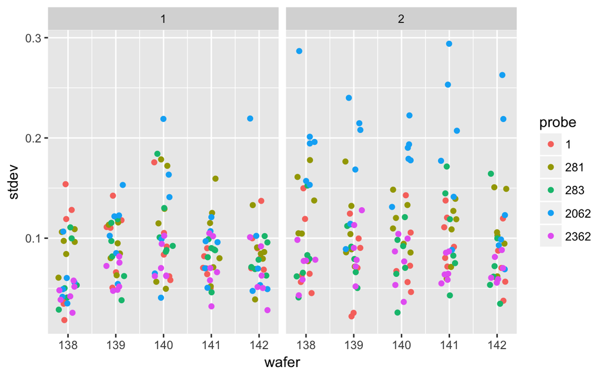

```r
ggplot(mpc61a_clean) +
  geom_jitter(aes(x = wafer, y = stdev, colour = as.factor(probe)), width = 0.2, height = 0) +
  facet_wrap(~ run) +
  labs(colour = "probe")
```

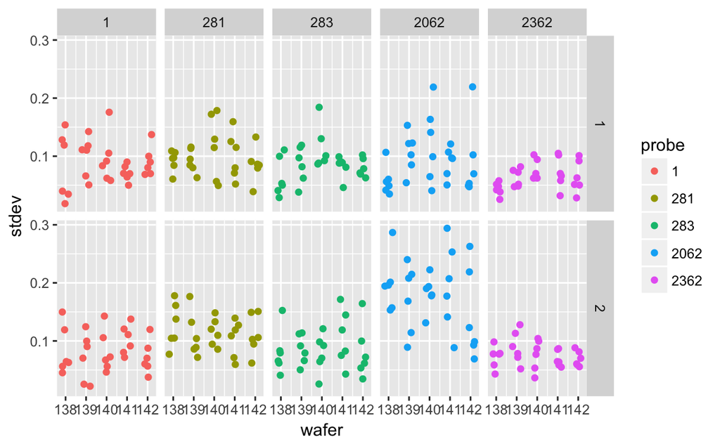

```r
ggplot(mpc61a_clean) +
  geom_jitter(aes(x = wafer, y = stdev, colour = as.factor(probe)), width = 0.2, height = 0) +
  facet_grid(run ~ probe) +
  labs(colour = "probe")
```

### Analysis of reproducibility and stability

#### Effects of days and long-term stability

[2.6.1.4 Effects of days and long-term stability](http://www.itl.nist.gov/div898/handbook/mpc/section6/mpc614.htm)

For each wafer, I’d like to look at the reproducability and long-term stability

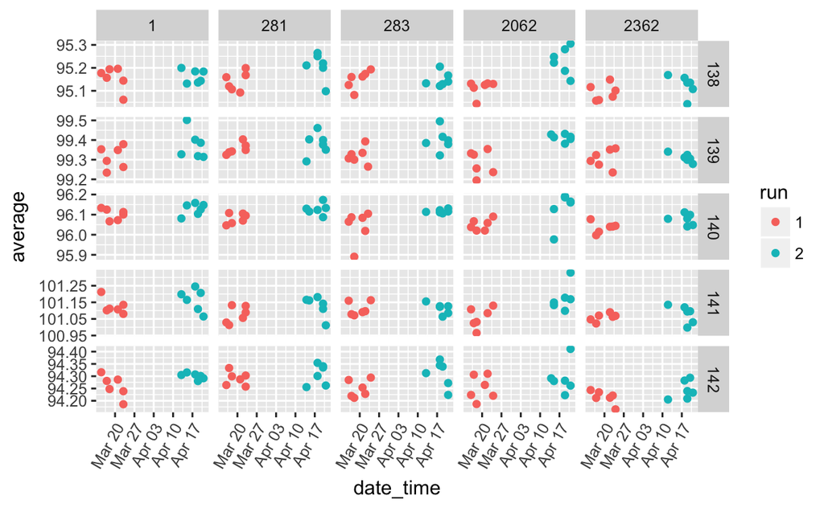

```r
ggplot(mpc61a_clean) +
  geom_point(aes(x = date_time, y = average, colour = as.factor(run))) +
  facet_grid(wafer ~ probe, scales = "free_y") +
  theme(axis.text.x = element_text(angle = 60, hjust = 1)) +
  labs(colour = "run")
```

### Analysis of bias (????)

#### Differences among gauges

[2.6.1.5 Differences among 5 probes](http://www.itl.nist.gov/div898/handbook/mpc/section6/mpc615.htm)

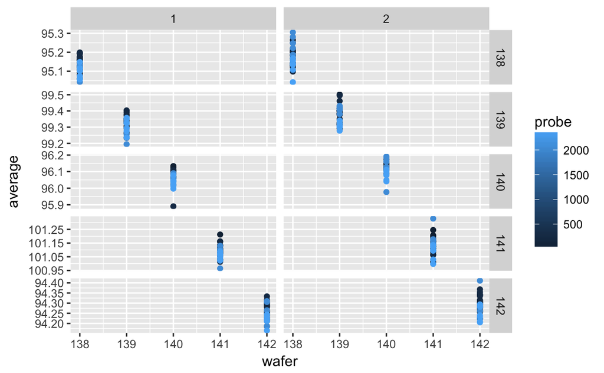

```r
ggplot(mpc61a_clean) +
  geom_point(aes(x = wafer, y = average, colour = probe)) +
  facet_grid(wafer ~ run, scales = "free_y")
```

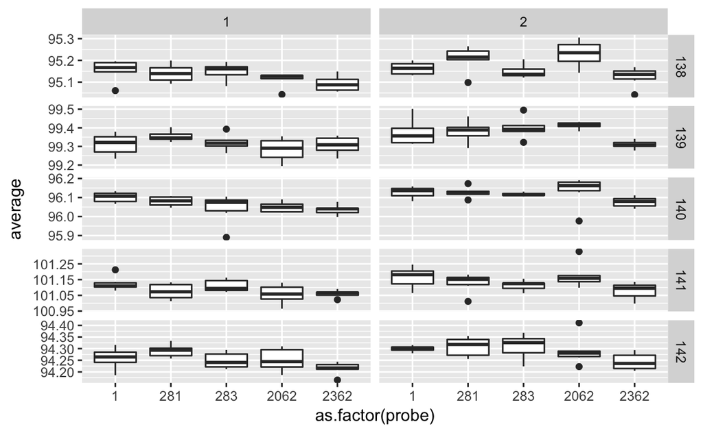

```r
ggplot(mpc61a_clean) +
  geom_boxplot(aes(x = as.factor(probe), y = average)) +
  facet_grid(wafer ~ run, scales = "free_y")
```

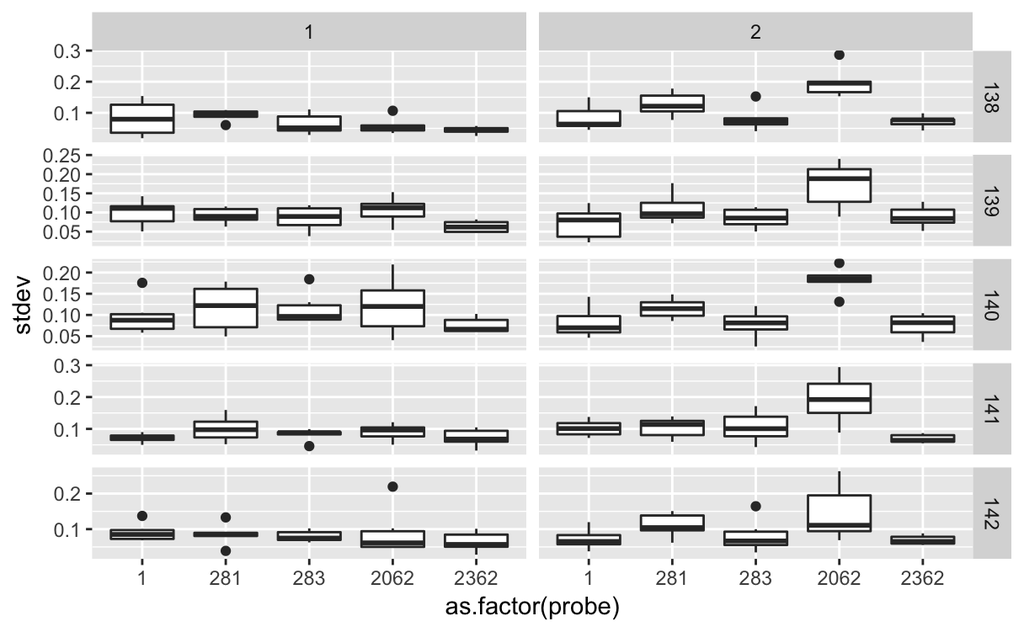

```r
ggplot(mpc61a_clean) +
  geom_boxplot(aes(x = as.factor(probe), y = stdev)) +
  facet_grid(wafer ~ run, scales = "free_y")
```

### SixSigma

```
Complete model (with interaction):

               Df Sum Sq Mean Sq   F value   Pr(>F)
wafer           4 2032.9   508.2 284264.23  < 2e-16
probe           4    0.1     0.0     17.23 1.19e-05
wafer:probe    16    0.0     0.0      0.60    0.883
Repeatability 275    0.8     0.0
Total         299 2033.9

alpha for removing interaction: 0.05


Reduced model (without interaction):

               Df Sum Sq Mean Sq   F value   Pr(>F)
wafer           4 2032.9   508.2 174297.55  < 2e-16
probe           4    0.1     0.0     10.56 5.27e-08
Repeatability 291    0.8     0.0
Total         299 2033.9

Gage R&R

                       VarComp %Contrib
Total Gage R&R    0.0033806219     0.04
  Repeatability   0.0029158952     0.03
  Reproducibility 0.0004647267     0.01
    probe         0.0004647267     0.01
Part-To-Part      8.4705080077    99.96
Total Variation   8.4738886295   100.00

                      StdDev   StudyVar %StudyVar
Total Gage R&R    0.05814312  0.3488587      2.00
  Repeatability   0.05399903  0.3239942      1.86
  Reproducibility 0.02155752  0.1293451      0.74
    probe         0.02155752  0.1293451      0.74
Part-To-Part      2.91041372 17.4624823     99.98
Total Variation   2.91099444 17.4659666    100.00

Number of Distinct Categories = 70
```

[figure not shown]

```r
library(SixSigma)
ss.rr(var = average, part = wafer, appr = probe, data = mpc61a_clean, main = "SixSigma analysis of MPC61.DAT file", sub = "for MST 6600")
```

```
Complete model (with interaction):

               Df Sum Sq Mean Sq F value Pr(>F)
run             1    0.2   0.179  14.529 0.0189
probe           4    0.1   0.031   2.502 0.1980
run:probe       4    0.0   0.012   0.002 1.0000
Repeatability 290 2033.6   7.012
Total         299 2033.9

alpha for removing interaction: 0.05


Reduced model (without interaction):

               Df Sum Sq Mean Sq F value Pr(>F)
run             1    0.2   0.179   0.026  0.872
probe           4    0.1   0.031   0.004  1.000
Repeatability 294 2033.6   6.917
Total         299 2033.9

Gage R&R

                   VarComp %Contrib
Total Gage R&R    6.917018      100
  Repeatability   6.917018      100
  Reproducibility 0.000000        0
    probe         0.000000        0
Part-To-Part      0.000000        0
Total Variation   6.917018      100

                    StdDev StudyVar %StudyVar
Total Gage R&R    2.630022 15.78013       100
  Repeatability   2.630022 15.78013       100
  Reproducibility 0.000000  0.00000         0
    probe         0.000000  0.00000         0
Part-To-Part      0.000000  0.00000         0
Total Variation   2.630022 15.78013       100

Number of Distinct Categories = 1
```

[figure not shown]

```r
ss.rr(var = average, part = run, appr = probe, data = mpc61a_clean, main = "SixSigma analysis of MPC61.DAT file", sub = "for MST 6600 test")
```

Go back to RStudio for SixSigma

### Looking aheaad (R for Data Science: Chapter 5 - Data Transformation)

#### Look at Guage R & R data

- Principles of tidy data **tidyr** package (part of the **tidyverse** package)
  - Most common
    - spread()
    - gather()
  - Less common
    - separate()
    - unite()
- Data transfomration with the **dplyr** package (part of the **tidyverse** package)
  - Most common
    - filter()
    - mutate()
    - group_by() & summarise()
  - less common for visulazation
    - arrange()
    - select()
    - rename()

### Examples using the `mpc61_clean` data

#### Using the `filter()` function

```r
mpc61_probe2062 <- filter(mpc61a_clean, probe == 2062)
mpc61_probe2062
```

| run | wafer | probe | month | day | operator | temp | average | stdev | date_time |
| --- | --- | --- | --- | --- | --- | --- | --- | --- | --- |
| 1 | 138 | 2062 | 3 | 16 | 1 | 22.97 | 95.1311 | 0.1066 | 2017-03-16 |
| 1 | 138 | 2062 | 3 | 17 | 1 | 22.98 | 95.1132 | 0.0415 | 2017-03-17 |
| 1 | 138 | 2062 | 3 | 18 | 1 | 23.16 | 95.0432 | 0.0491 | 2017-03-18 |
| 1 | 138 | 2062 | 3 | 21 | 1 | 23.16 | 95.1254 | 0.0603 | 2017-03-21 |
| 1 | 138 | 2062 | 3 | 22 | 1 | 23.28 | 95.1322 | 0.0561 | 2017-03-22 |
| 1 | 138 | 2062 | 3 | 24 | 2 | 23.19 | 95.1299 | 0.0349 | 2017-03-24 |
| 1 | 139 | 2062 | 3 | 16 | 1 | 22.94 | 99.3324 | 0.1531 | 2017-03-16 |
| 1 | 139 | 2062 | 3 | 17 | 1 | 23.08 | 99.3254 | 0.0543 | 2017-03-17 |
| 1 | 139 | 2062 | 3 | 18 | 1 | 23.15 | 99.2555 | 0.1024 | 2017-03-18 |
| 1 | 139 | 2062 | 3 | 18 | 1 | 23.18 | 99.1946 | 0.0851 | 2017-03-18 |

[output cut: 50 more lines]

### Analysis using new data frame

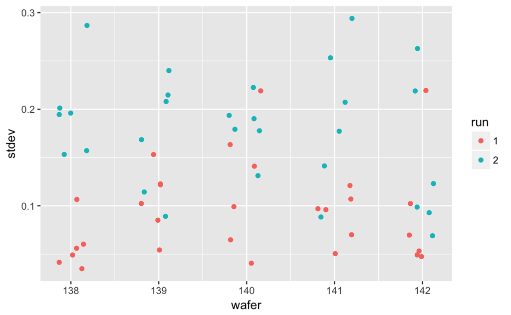

```r
ggplot(mpc61_probe2062) +
  geom_jitter(aes(x = wafer, y = stdev, colour = as.factor(run)), width = 0.2, height = 0) +
  labs(colour = "run")
```

#### comparison of best and worst

From the SixSigma work (and visually) we saw that 2062 was the worse performing probe and 2362 was one of the best.

```r
mpc61_probes_good_bad <- filter(mpc61a_clean, probe == c(2062, 2362))
mpc61_probes_good_bad
```

| run | wafer | probe | month | day | operator | temp | average | stdev | date_time |
| --- | --- | --- | --- | --- | --- | --- | --- | --- | --- |
| 1 | 138 | 2062 | 3 | 16 | 1 | 22.97 | 95.1311 | 0.1066 | 2017-03-16 |
| 1 | 138 | 2062 | 3 | 18 | 1 | 23.16 | 95.0432 | 0.0491 | 2017-03-18 |
| 1 | 138 | 2062 | 3 | 22 | 1 | 23.28 | 95.1322 | 0.0561 | 2017-03-22 |
| 1 | 138 | 2362 | 3 | 17 | 1 | 23.01 | 95.0569 | 0.0577 | 2017-03-17 |
| 1 | 138 | 2362 | 3 | 22 | 1 | 23.23 | 95.1487 | 0.0386 | 2017-03-22 |
| 1 | 138 | 2362 | 3 | 24 | 2 | 23.10 | 95.1010 | 0.0420 | 2017-03-24 |
| 1 | 139 | 2062 | 3 | 16 | 1 | 22.94 | 99.3324 | 0.1531 | 2017-03-16 |
| 1 | 139 | 2062 | 3 | 18 | 1 | 23.15 | 99.2555 | 0.1024 | 2017-03-18 |
| 1 | 139 | 2062 | 3 | 22 | 1 | 23.27 | 99.3542 | 0.1227 | 2017-03-22 |
| 1 | 139 | 2362 | 3 | 17 | 1 | 23.02 | 99.3234 | 0.0723 | 2017-03-17 |

[output cut: 50 more lines]

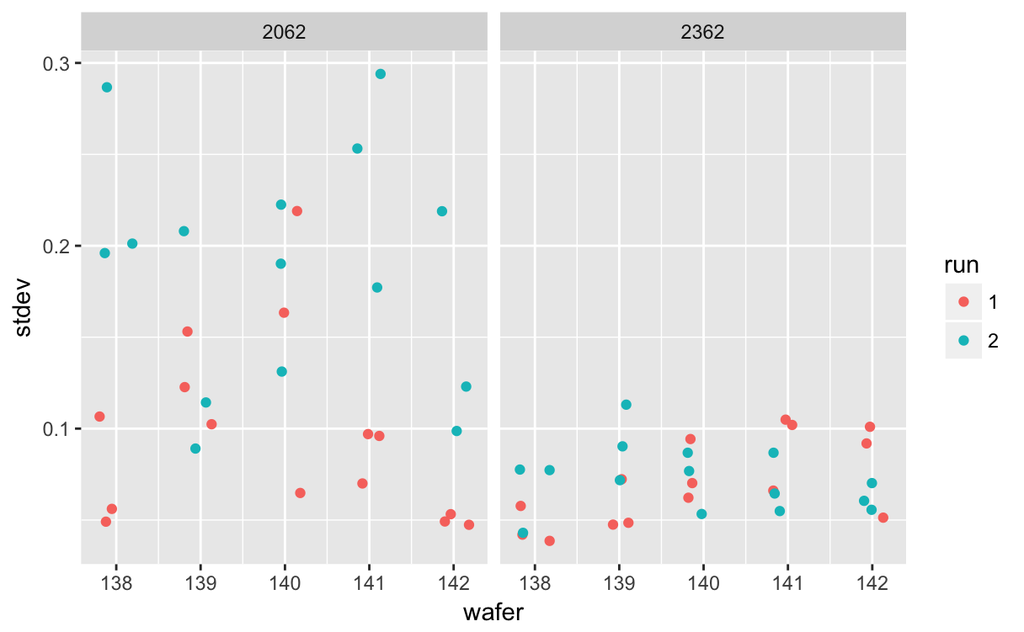

```r
ggplot(mpc61_probes_good_bad) +
  geom_jitter(aes(x = wafer, y = stdev, colour = as.factor(run)), width = 0.2, height = 0) +
  facet_wrap(~ probe) +
  labs(colour = "run")
```

#### group_by() & summarise()

We’ve been able to make some great graphics, but what about hte numbers! (Editoral comment: Someone will always ask for a summary report, even if the graphics clearly show the answer.)

```r
by_wafer <- group_by(mpc61a_clean, wafer)
by_wafer
```

| run | wafer | probe | month | day | operator | temp | average | stdev | date_time |
| --- | --- | --- | --- | --- | --- | --- | --- | --- | --- |
| 1 | 138 | 1 | 3 | 15 | 1 | 22.98 | 95.1772 | 0.1191 | 2017-03-15 |
| 1 | 138 | 1 | 3 | 17 | 1 | 23.02 | 95.1567 | 0.0183 | 2017-03-17 |
| 1 | 138 | 1 | 3 | 18 | 1 | 22.79 | 95.1937 | 0.1282 | 2017-03-18 |
| 1 | 138 | 1 | 3 | 21 | 1 | 23.17 | 95.1959 | 0.0398 | 2017-03-21 |
| 1 | 138 | 1 | 3 | 23 | 2 | 23.25 | 95.1442 | 0.0346 | 2017-03-23 |
| 1 | 138 | 1 | 3 | 23 | 1 | 23.20 | 95.0610 | 0.1539 | 2017-03-23 |
| 1 | 138 | 281 | 3 | 16 | 1 | 22.99 | 95.1591 | 0.0963 | 2017-03-16 |
| 1 | 138 | 281 | 3 | 17 | 1 | 22.97 | 95.1195 | 0.0606 | 2017-03-17 |
| 1 | 138 | 281 | 3 | 18 | 1 | 22.83 | 95.1065 | 0.0842 | 2017-03-18 |
| 1 | 138 | 281 | 3 | 21 | 1 | 23.28 | 95.0925 | 0.0973 | 2017-03-21 |

[output cut: 290 more lines]

```r
mpc61a_clean
```

| run | wafer | probe | month | day | operator | temp | average | stdev | date_time |
| --- | --- | --- | --- | --- | --- | --- | --- | --- | --- |
| 1 | 138 | 1 | 3 | 15 | 1 | 22.98 | 95.1772 | 0.1191 | 2017-03-15 |
| 1 | 138 | 1 | 3 | 17 | 1 | 23.02 | 95.1567 | 0.0183 | 2017-03-17 |
| 1 | 138 | 1 | 3 | 18 | 1 | 22.79 | 95.1937 | 0.1282 | 2017-03-18 |
| 1 | 138 | 1 | 3 | 21 | 1 | 23.17 | 95.1959 | 0.0398 | 2017-03-21 |
| 1 | 138 | 1 | 3 | 23 | 2 | 23.25 | 95.1442 | 0.0346 | 2017-03-23 |
| 1 | 138 | 1 | 3 | 23 | 1 | 23.20 | 95.0610 | 0.1539 | 2017-03-23 |
| 1 | 138 | 281 | 3 | 16 | 1 | 22.99 | 95.1591 | 0.0963 | 2017-03-16 |
| 1 | 138 | 281 | 3 | 17 | 1 | 22.97 | 95.1195 | 0.0606 | 2017-03-17 |
| 1 | 138 | 281 | 3 | 18 | 1 | 22.83 | 95.1065 | 0.0842 | 2017-03-18 |
| 1 | 138 | 281 | 3 | 21 | 1 | 23.28 | 95.0925 | 0.0973 | 2017-03-21 |

[output cut: 290 more lines]

It doesn’t look like anything has changed, but R has grouped the data by wafer. We can see this when we use the `summarise()` function.

```r
wafer_summary <- summarise(by_wafer, average = mean(average))
wafer_summary
```

| wafer | average |
| --- | --- |
| 138 | 95.15253 |
| 139 | 99.34540 |
| 140 | 96.08907 |
| 141 | 101.10889 |
| 142 | 94.27187 |

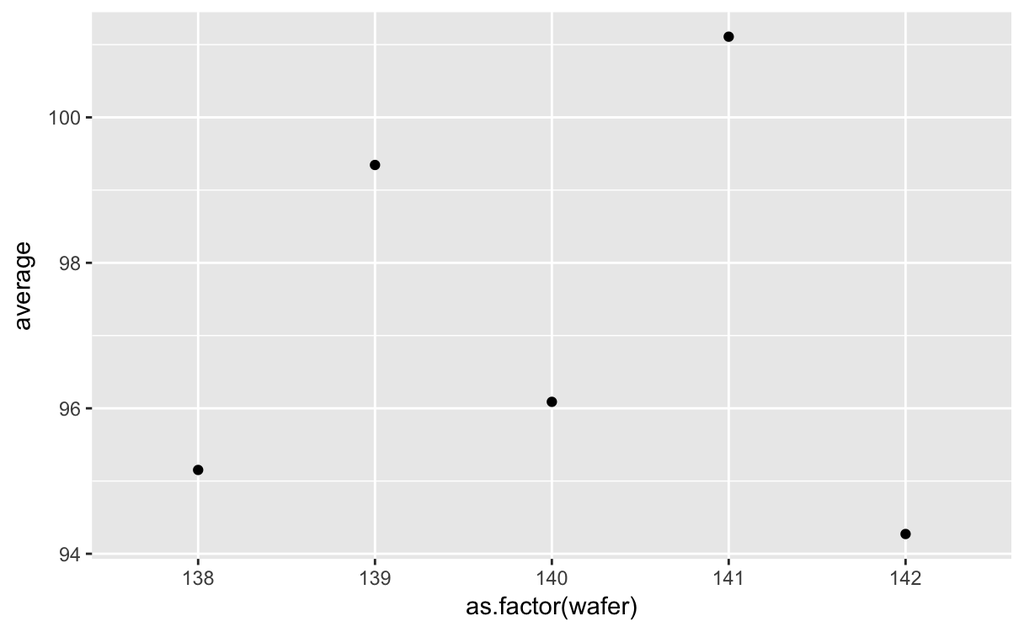

```r
ggplot(wafer_summary) +
  geom_point(aes(x = as.factor(wafer), y = average))
```

#### We aren’t limited to grouping by a single variable

```r
by_wafer_probe <- group_by(mpc61a_clean, wafer, probe)
by_wafer_probe
```

| run | wafer | probe | month | day | operator | temp | average | stdev | date_time |
| --- | --- | --- | --- | --- | --- | --- | --- | --- | --- |
| 1 | 138 | 1 | 3 | 15 | 1 | 22.98 | 95.1772 | 0.1191 | 2017-03-15 |
| 1 | 138 | 1 | 3 | 17 | 1 | 23.02 | 95.1567 | 0.0183 | 2017-03-17 |
| 1 | 138 | 1 | 3 | 18 | 1 | 22.79 | 95.1937 | 0.1282 | 2017-03-18 |
| 1 | 138 | 1 | 3 | 21 | 1 | 23.17 | 95.1959 | 0.0398 | 2017-03-21 |
| 1 | 138 | 1 | 3 | 23 | 2 | 23.25 | 95.1442 | 0.0346 | 2017-03-23 |
| 1 | 138 | 1 | 3 | 23 | 1 | 23.20 | 95.0610 | 0.1539 | 2017-03-23 |
| 1 | 138 | 281 | 3 | 16 | 1 | 22.99 | 95.1591 | 0.0963 | 2017-03-16 |
| 1 | 138 | 281 | 3 | 17 | 1 | 22.97 | 95.1195 | 0.0606 | 2017-03-17 |
| 1 | 138 | 281 | 3 | 18 | 1 | 22.83 | 95.1065 | 0.0842 | 2017-03-18 |
| 1 | 138 | 281 | 3 | 21 | 1 | 23.28 | 95.0925 | 0.0973 | 2017-03-21 |

[output cut: 290 more lines]

#### Again, the data frame looks the same; however,

```r
wafer_probe_summary <- summarise(by_wafer_probe, sd_ave = sd(average), n = n())
wafer_probe_summary
```

| wafer | probe | sd_ave | n |
| --- | --- | --- | --- |
| 138 | 1 | 0.03951293 | 12 |
| 138 | 281 | 0.05955258 | 12 |
| 138 | 283 | 0.03428606 | 12 |
| 138 | 2062 | 0.07760598 | 12 |
| 138 | 2362 | 0.04231678 | 12 |
| 139 | 1 | 0.07033149 | 12 |
| 139 | 281 | 0.04498085 | 12 |
| 139 | 283 | 0.06304756 | 12 |
| 139 | 2062 | 0.08098582 | 12 |
| 139 | 2362 | 0.03503046 | 12 |

[output cut: 15 more lines]

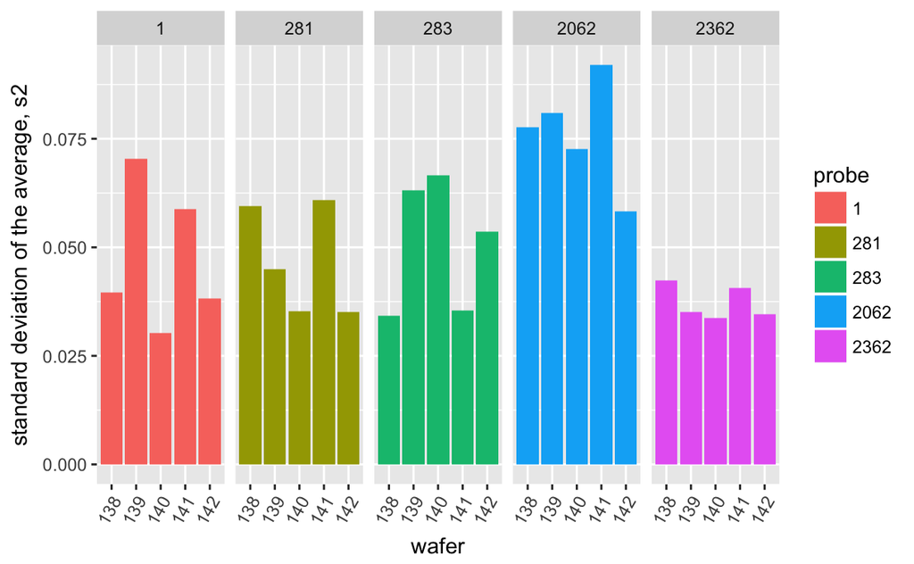

```r
ggplot(wafer_probe_summary) +
  geom_bar(aes(x = as.factor(wafer), y = sd_ave, fill = as.factor(probe)), stat = "identity") +
  facet_grid(. ~ probe) +
  theme(axis.text.x = element_text(angle = 60, hjust = 1)) +
  labs(fill = "probe", x = "wafer", y = "standard deviation of the average, s2")
```